# penguins closeread prototype

Between 2007 and 2009, researchers collected data on over 340 brush-tailed penguins, or penguins of the genus *Pygoscelis*. Dr. Kristen Gorman led the study as part of the Palmer Long Term Ecological Research (Palmer LTER) program, a program funded by the US National Science Foundation (NSF) to research the Antarctic pelagic marine ecosystem. The researchers collected measurements of three species of *Pygoscelis* penguins—Adélie, Chinstrap, and Gentoo penguins—nesting on three islands in the Palmer Archipelago in Antarctica (Gorman et al. 2014; Horst et al. 2020).

The penguins were observed on Biscoe Island, Dream Island, and Torgersen Island.

Gentoo penguins were observed only on Biscoe Island.

Chinstrap penguins were observed only on Dream Island.

Adélie penguins were the only species observed on all three islands, and the only species observed on Torgersen Island.

The data include a bit more Adélie than Gentoo penguins, and fewer Chinstrap penguins. Within each species, there is a balance of male and female penguins.

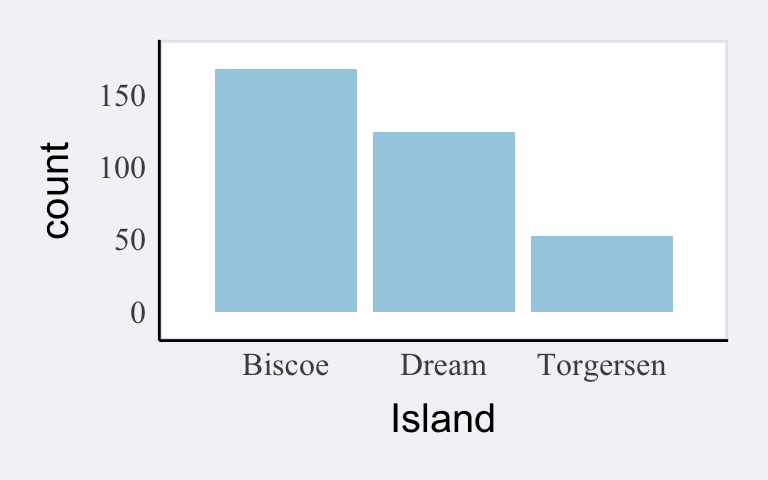

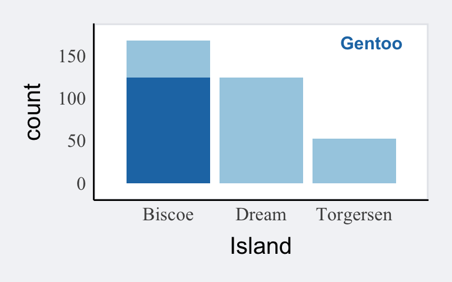

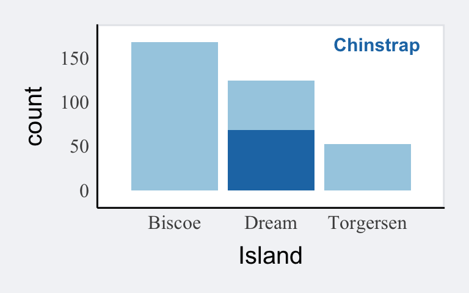

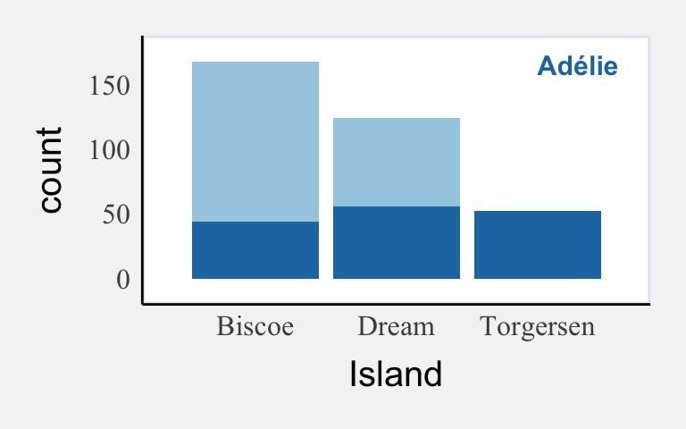

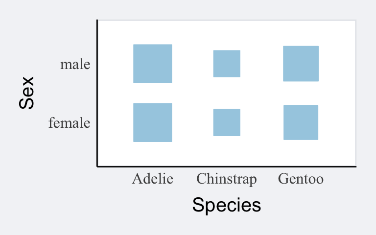

### Let’s explore how the species physically differ from one another.

First, let’s look at the penguins’ body measurements.

Gentoo penguins are the largest, with greater body mass and longer flippers than the other two species.

Adélie penguins are smaller than Gentoo penguins, with lower body mass and shorter flippers

Chinstrap penguins are similar in size to Adélie penguins, also smaller than Gentoo penguins.

So body size distinguishes Gentoo penguins from the rest, but we can’t tell apart Adélie and Chinstrap penguins based on body mass and flipper length alone.

Now let’s look at the penguins’ bill measurements.

Chinstrap penguins tend to have the largest bills, with long and deep bills.

Adélie penguins tend to have deep bills, similar to Chinstrap penguins, but Adélie bills are shorter.

Gentoo penguins tend to have long bills, similar to Chinstrap penguins, but Gentoo bills are shallower.

So, bill length and depth separate all three species: Chinstraps have long, deep bills, Adélies have short, deep bills, and Gentoo have long, shallow bills. Body size distinguishes Gentoos, and bill shape can distinguish the rest.

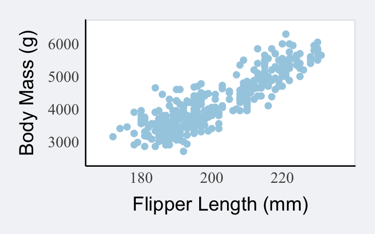

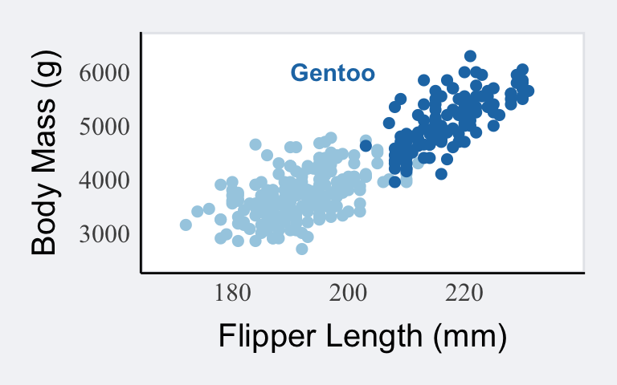

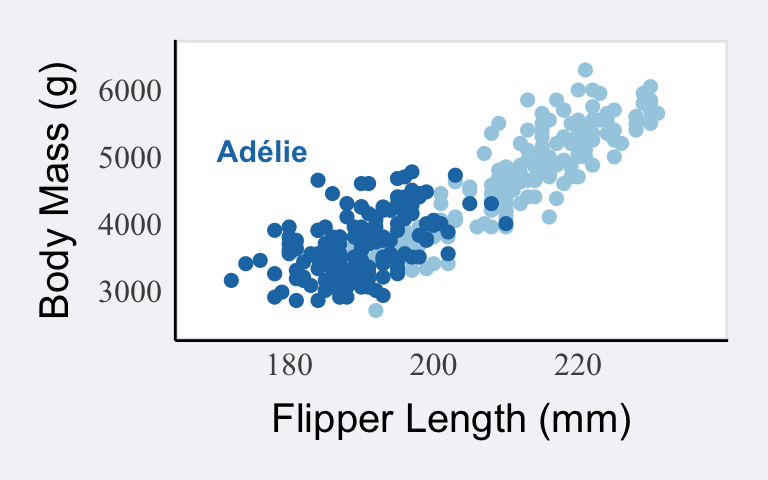

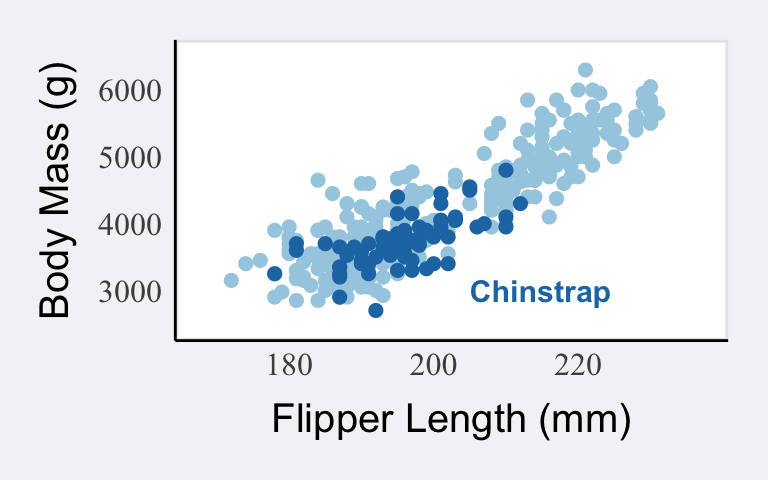

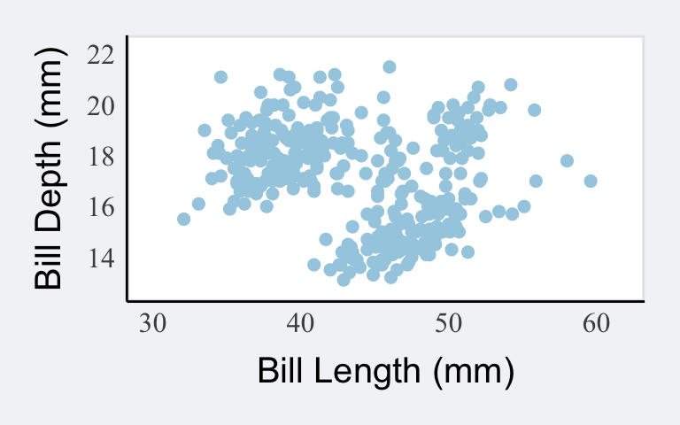

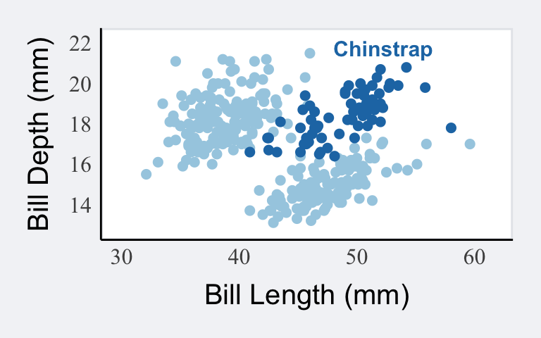

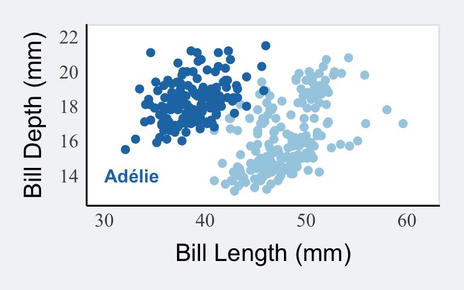

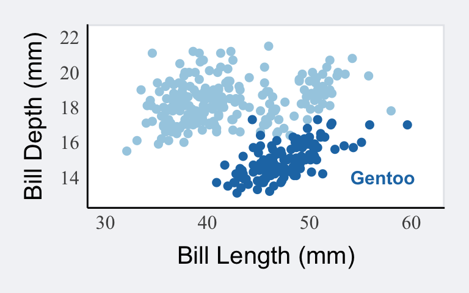

## References

Gorman, Kristen B., Tony D. Williams, and William R. Fraser. 2014. “Ecological Sexual Dimorphism and Environmental Variability Within a Community of Antarctic Penguins (Genus Pygoscelis).” *PLOS ONE* 9 (3): e90081. https://doi.org/10.1371/journal.pone.0090081.

Horst, Allison Marie, Alison Presmanes Hill, and Kristen B. Gorman. 2020. *Palmerpenguins: Palmer Archipelago (Antarctica) Penguin Data*. https://doi.org/10.5281/zenodo.3960218.